# Prediction Assignment

Brandon Chia

February 24, 2016

## 1. Abstract

Using devices such as Jawbone Up, Nike FuelBand, and Fitbit it is now possible to collect a large amount of data about personal activity relatively inexpensively. These type of devices are part of the quantified self movement - a group of enthusiasts who take measurements about themselves regularly to improve their health, to find patterns in their behavior, or because they are tech geeks. One thing that people regularly do is quantify how much of a particular activity they do, but they rarely quantify how well they do it. In this project, your goal will be to use data from accelerometers on the belt, forearm, arm, and dumbell of 6 participants. They were asked to perform barbell lifts correctly and incorrectly in 5 different ways. More information is available from the website [here:](http://groupware.les.inf.puc-rio.br/har)

## 2. Data Analysis

### 2.1 Data Sourse

The training and test dataset for this project are available here:

[training dataset](https://d396qusza40orc.cloudfront.net/predmachlearn/pml-training.csv)

[test dataset](https://d396qusza40orc.cloudfront.net/predmachlearn/pml-testing.csv)

The data for this project come from this [source:](http://groupware.les.inf.puc-rio.br/har). If you use the document you create for this class for any purpose please cite them as they have been very generous in allowing their data to be used for this kind of assignment.

### 2.2 Get Data and Clean Data

#### 2.2.1 Read the data and delete useless columns

```r
library(caret);library(randomForest);library(e1071);library(corrplot)
temp1 <- tempfile();temp2 <- tempfile()
download.file("https://d396qusza40orc.cloudfront.net/predmachlearn/pml-training.csv",destfile=temp1)
download.file("https://d396qusza40orc.cloudfront.net/predmachlearn/pml-testing.csv",destfile=temp2)
train <- read.csv(temp1,header = TRUE,na.strings = c('','NA'))
test <- read.csv(temp2, header = TRUE,na.strings = c('','NA'))
index <- which(colSums(is.na(train))!=0)
train <- train[,-index]
train <- train[,-(1:7)]
```

#### 2.2.2 Split training dataset for fitting model and cross-validation

```r
library(caret)
inTrain = createDataPartition(y = train$classe, p = 0.6, list = FALSE)
trainset<-train[inTrain, ]
validset<- train[-inTrain, ]
```

### 2.3 Fit Model

- Part 1: PCA analysis

```r
library(randomForest)
```

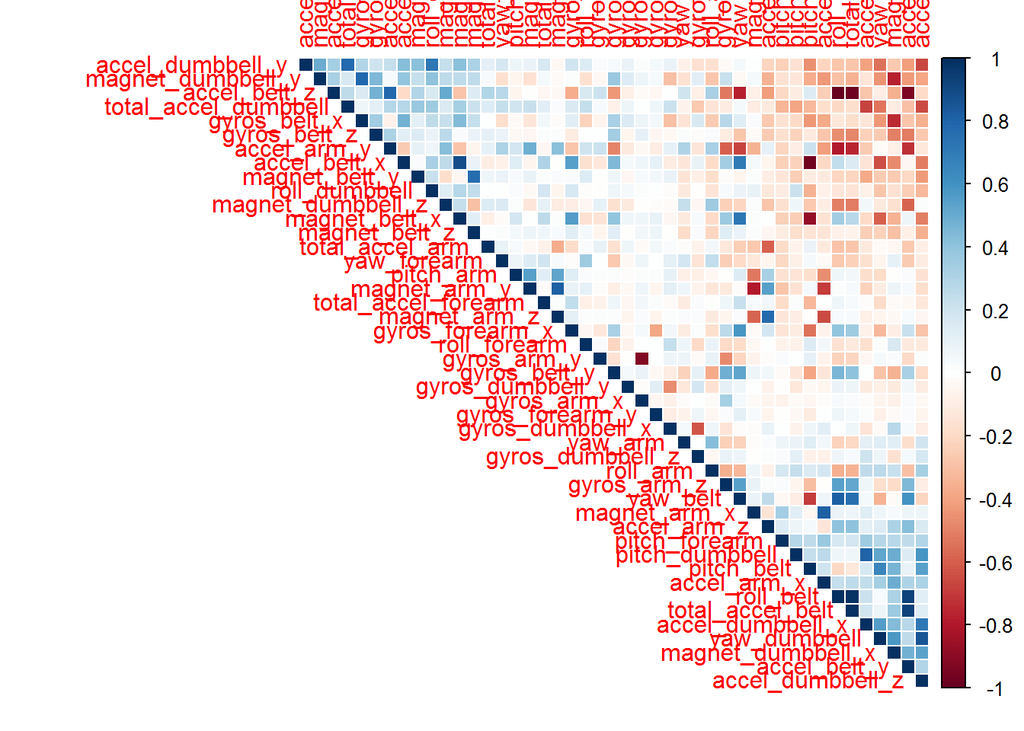

```r
corrplot::corrplot(cor(trainset[,1:45]),order='FPC',method='color',type='upper')
```

```r
pre<- preProcess(trainset[,1:45],method='pca',thresh=0.99)
train1 <- predict(pre,trainset[,1:45])
valid1 <- predict(pre,validset[,1:45])
```

As you could see from legend right behind the plot, there are several variables closely relative (postively or negatively) to each other. So, it is intuitive to hire PCA.

- Part 2: Fitting the model and cross valid.

```r
fit1 <-randomForest(trainset$classe~.,data=trainset,ntree=25,importance=TRUE)
valid1 <- predict(fit1,validset)
confusionMatrix(valid1,validset$classe)
```

```
## Confusion Matrix and Statistics
##
##           Reference
## Prediction    A    B    C    D    E
##          A 2229   11    0    0    0
##          B    0 1501   19    1    0
##          C    0    6 1346   26    2
##          D    2    0    3 1257    3
##          E    1    0    0    2 1437
##
## Overall Statistics
##
##                Accuracy : 0.9903
##                  95% CI : (0.9879, 0.9924)
##     No Information Rate : 0.2845
##     P-Value [Acc > NIR] : < 2.2e-16
##
##                   Kappa : 0.9877
##  Mcnemar's Test P-Value : NA
##
## Statistics by Class:
##
##                      Class: A Class: B Class: C Class: D Class: E
## Sensitivity            0.9987   0.9888   0.9839   0.9774   0.9965
## Specificity            0.9980   0.9968   0.9948   0.9988   0.9995
## Pos Pred Value         0.9951   0.9869   0.9754   0.9937   0.9979
## Neg Pred Value         0.9995   0.9973   0.9966   0.9956   0.9992
## Prevalence             0.2845   0.1935   0.1744   0.1639   0.1838
## Detection Rate         0.2841   0.1913   0.1716   0.1602   0.1832
## Detection Prevalence   0.2855   0.1939   0.1759   0.1612   0.1835
## Balanced Accuracy      0.9983   0.9928   0.9893   0.9881   0.9980
```

#### 2.3.2 Method 2: RF

- Fit the model and cross-valid

```r
fit2 <- train(classe~.,data=trainset,methods='rf',tuneLength = 1,ntree = 25)
valid2 <- predict(fit2,validset)
confusionMatrix(valid2,validset$classe)
```

```
## Confusion Matrix and Statistics
##
##           Reference
## Prediction    A    B    C    D    E
##          A 2230   19    0    0    0
##          B    0 1491   17    2    3
##          C    1    7 1349   18    3
##          D    0    0    2 1265    4
##          E    1    1    0    1 1432
##
## Overall Statistics
##
##                Accuracy : 0.9899
##                  95% CI : (0.9875, 0.992)
##     No Information Rate : 0.2845
##     P-Value [Acc > NIR] : < 2.2e-16
##
##                   Kappa : 0.9873
##  Mcnemar's Test P-Value : NA
##
## Statistics by Class:
##
##                      Class: A Class: B Class: C Class: D Class: E
## Sensitivity            0.9991   0.9822   0.9861   0.9837   0.9931
## Specificity            0.9966   0.9965   0.9955   0.9991   0.9995
## Pos Pred Value         0.9916   0.9855   0.9790   0.9953   0.9979
## Neg Pred Value         0.9996   0.9957   0.9971   0.9968   0.9984
## Prevalence             0.2845   0.1935   0.1744   0.1639   0.1838
## Detection Rate         0.2842   0.1900   0.1719   0.1612   0.1825
## Detection Prevalence   0.2866   0.1928   0.1756   0.1620   0.1829
## Balanced Accuracy      0.9979   0.9894   0.9908   0.9914   0.9963
```

## 3. Predict test dataset

```r
predict(fit2,test)
```

```
##  [1] B A B A A E D B A A B C B A E E A B B B
## Levels: A B C D E
```